# 59_Statistical_Inference

# Simulation To Verify Central Limit Theorem On Exponential Distribution

This project investigates the exponential distrbution and uses it to verify the central limit theorem. A thousand simulations are run each with 40 samples taken from an exponential distribution with rate parameter lambda = 0.2. Theoretical means and variances of the sample means is compared with the observed values and normality of the distribution is checked.

## Simulations

40 random samples were drawn from an exponential distribution with rate parameter 0.2 using the rexp(n,lambda) function. The mean of each sample was taken and a vector of samples means was constructed for further analysis.

```r
set.seed(2)
no_Of_Simulations = 1000
n = 40
lambda = 0.2
means = NULL
for(i in 1:no_Of_Simulations)
{
  sample = rexp(n,lambda)
  means = c(means,mean(sample))
}
```

## Comparison Of Mean Of Sample Mean To Theoretical Mean

According to CLT, the mean of sample means is normally distributed with mean equal to the actual theoretical mean of the original distribution. Thus, mean of samples means is expected to be equal to the theoretical mean of 1/lambda.

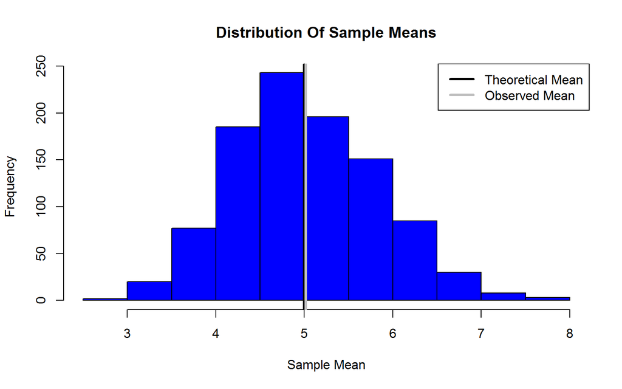

```r
hist(means,main='Distribution Of Sample Means',xlab='Sample Mean',col='blue')
abline(v=1/lambda,col='black',lwd=3)
abline(v=mean(means),col='grey',lwd=3)
legend(x='topright',col=c('black','grey'),legend=c("Theoretical Mean","Observed Mean"),lwd=3)
```

### Comparison

```r
# Theoretical Mean
m1 = 1/lambda
print(m1)
```

```
## [1] 5
```

```r
# Observed Mean
m2 = mean(means)
print(m2)
```

```
## [1] 5.016356
```

```r
# Absolute Difference
adiff = abs(m1 - m2)
print(adiff)
```

```
## [1] 0.01635615
```

- We can see that the theoretical and observed values are very close to each other.

**Comparison Of Variance Of Sample Mean To Theoretical Variance**

According to CLT, the mean of sample means is normally distributed with standard deviation equal to the actual theoretical standard deviation of the original distribution divided by the square root of the sample size. Thus, variance of samples means is expected to be equal to the theoretical variance of 1/(lambda x lambda x 40).

```r
# Compare Variance Of Sample Means To Theoretical Variance
# Theoretical Variance
v1 = (1/(lambda*lambda*n))
print(v1)
```

```
## [1] 0.625
```

```r
# Observed Variance
v2 = var(means)
print(v2)
```

```
## [1] 0.6691305
```

```r
# Absolute Difference
adiff = abs(v1-v2)
print(adiff)
```

```
## [1] 0.04413047
```

- We can see that the theoretical and observed values are very close to each other.

## Approximate Normality Verification

We will plot a histogram of the sample means and overlay that with the theoretical normal distribution that is with mean (1/lambda) and variance 1/(lamda x lambda x 40).

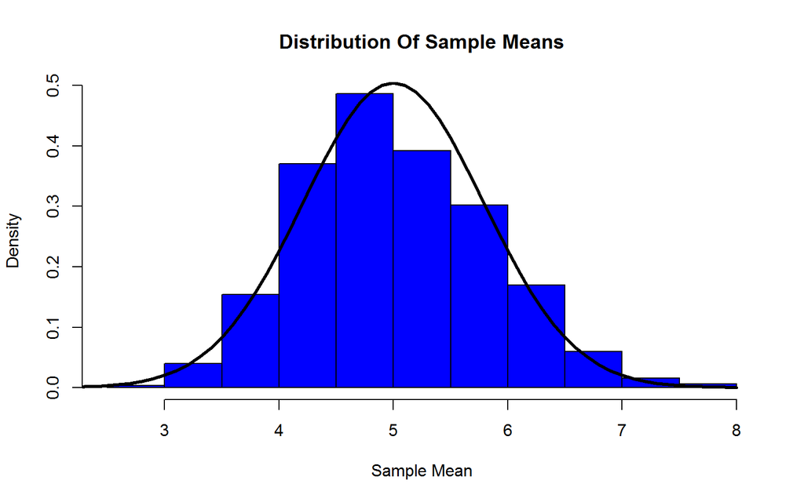

```r
# Showing Approximate Normality
hist(means,main='Distribution Of Sample Means',xlab='Sample Mean',col='blue',prob=T)
x = seq(-3,8,0.1)
y = dnorm(x,mean=m1,sd=sqrt(v1))
lines(x,y,lwd=3)
```

We can see from the plot that the distribution of sample means is approximately normal with the theoretical values of mean and standard deviation.

## Conclusion

Based on the above results, we can see that the theoretical mean and variance of the sample means matches the observed values and also that the distribution of the observed sample means is approximately normal.

```r
library(tidyverse)
```

# Inferential Data Analysis

relationship between tooth length growth and the dose and supplement given to them.

## explore Data

```r
df <- ToothGrowth
summary(df)
```

```
##       len        supp         dose
##  Min.   : 4.20   OJ:30   Min.   :0.500
##  1st Qu.:13.07   VC:30   1st Qu.:0.500
##  Median :19.25           Median :1.000
##  Mean   :18.81           Mean   :1.167
##  3rd Qu.:25.27           3rd Qu.:2.000
##  Max.   :33.90           Max.   :2.000
```

```r
# skimr::skim(df)
# df %>% group_by(dose) %>% skimr::skim()
#df %>% group_by(supp) %>% skimr::skim()
#df %>% group_by(supp,dose) %>% skimr::skim()
```

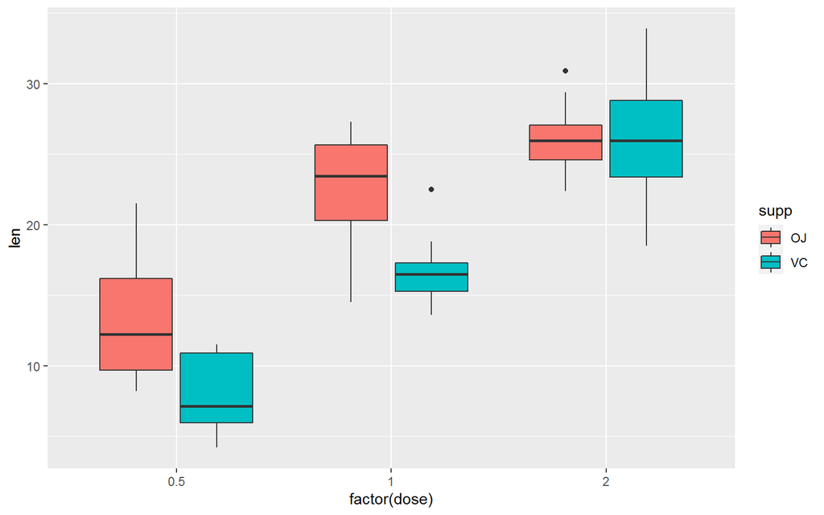

```r
ggplot(data = df) + geom_boxplot(aes(x =factor(dose), y= len , fill =supp))
```

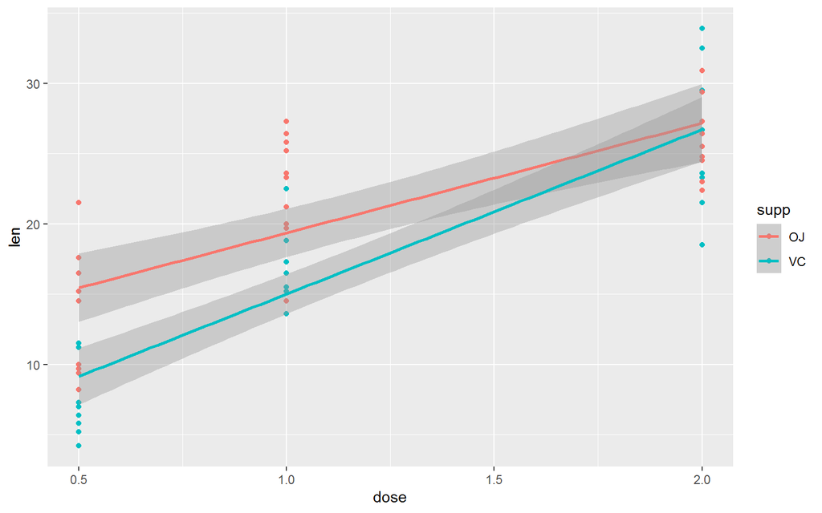

```r
ggplot(data = df ,aes(x= dose ,y=len ,col = supp)) +
  geom_point() +
  geom_smooth(method = lm)
```

Tooth length seems to be higher overall for Orange Juice as compared to Vitamin C, but there is not a major difference. Furthermore, for both types of supplements, it seems that tooth length increases with the dose amount. Also, for a dose of 0.5 and 1.0 mg/day, tooth length seems to be less for Vitamin C than Orange Juice, but for a higher dose of 2.0 mg/day there doesn’t seem to be much difference. We will test these claims using t-tests.

### Hypothesis 1

Does Tooth Length vary with dose amount for Orange Juice?

```r
# Does Tooth Length vary with Dose for Orange Juice?
df2 = df[df$supp=="OJ" & df$dose %in% c(0.5,1.0),]
t.test(len ~ dose, data = df2, var.equal=FALSE, paired = FALSE, alternative="greater")
```

```
##
##  Welch Two Sample t-test
##
## data:  len by dose
## t = -5.0486, df = 17.698, p-value = 1
## alternative hypothesis: true difference in means between group 0.5 and group 1 is greater than 0
## 95 percent confidence interval:
##  -12.72568       Inf
## sample estimates:
## mean in group 0.5   mean in group 1
##             13.23             22.70
```

```r
df2 = df[df$supp=="OJ" & df$dose %in% c(1.0,2.0),]
t.test(len ~ dose, data = df2, var.equal=FALSE, paired = FALSE, alternative="greater")
```

```
##
##  Welch Two Sample t-test
##
## data:  len by dose
## t = -2.2478, df = 15.842, p-value = 0.9804
## alternative hypothesis: true difference in means between group 1 and group 2 is greater than 0
## 95 percent confidence interval:
##  -5.971376       Inf
## sample estimates:
## mean in group 1 mean in group 2
##           22.70           26.06
```

We see that the p-value is greater than 0.05 in both cases. The null hypothesis that for Orange Juice, Tooth Length is less for 0.5 mg/day dose than that for 1.0 mg/day and growth for 1.0 mg/day is less than that of 2.0 mg/day, cannot be rejected.

### Hypothesis 2

Does Tooth Length vary with dose amount for Vitamin C?

```r
# Does Tooth Length vary with Dose for Vitamin C?
df2 = df[df$supp=="VC" & df$dose %in% c(0.5,1.0),]
t.test(len ~ dose, data = df2, var.equal=FALSE, paired = FALSE, alternative="greater")
```

```
##
##  Welch Two Sample t-test
##
## data:  len by dose
## t = -7.4634, df = 17.862, p-value = 1
## alternative hypothesis: true difference in means between group 0.5 and group 1 is greater than 0
## 95 percent confidence interval:
##  -10.83313       Inf
## sample estimates:
## mean in group 0.5   mean in group 1
##              7.98             16.77
```

```r
df2 = df[df$supp=="VC" & df$dose %in% c(1.0,2.0),]
t.test(len ~ dose, data = df2, var.equal=FALSE, paired = FALSE, alternative="greater")
```

```
##
##  Welch Two Sample t-test
##
## data:  len by dose
## t = -5.4698, df = 13.6, p-value = 1
## alternative hypothesis: true difference in means between group 1 and group 2 is greater than 0
## 95 percent confidence interval:
##  -12.39348       Inf
## sample estimates:
## mean in group 1 mean in group 2
##           16.77           26.14
```

same thing

### Hypothesis 3

Does Tooth Length vary with just Supplement Type?

```r
# Does Tooth Length vary with just supplement type?

t.test(len ~ supp, data = df, var.equal=FALSE, paired = FALSE)
```

```
##
##  Welch Two Sample t-test
##
## data:  len by supp
## t = 1.9153, df = 55.309, p-value = 0.06063
## alternative hypothesis: true difference in means between group OJ and group VC is not equal to 0
## 95 percent confidence interval:
##  -0.1710156  7.5710156
## sample estimates:
## mean in group OJ mean in group VC
##         20.66333         16.96333
```

### Hypothesis 4

```r
# Does Tooth Length vary with supplement type for Dose of 0.5
df2 = df[df$dose %in% c(0.5),]
t.test(len ~ supp, data = df, var.equal=FALSE, paired = FALSE,alternative="less")
```

```
##
##  Welch Two Sample t-test
##
## data:  len by supp
## t = 1.9153, df = 55.309, p-value = 0.9697
## alternative hypothesis: true difference in means between group OJ and group VC is less than 0
## 95 percent confidence interval:
##      -Inf 6.931731
## sample estimates:
## mean in group OJ mean in group VC
##         20.66333         16.96333
```

```r
# Does Tooth Length vary with supplement type for Dose of 1.0
df2 = df[df$dose %in% c(1.0),]
t.test(len ~ supp, data = df, var.equal=FALSE, paired = FALSE,alternative="less")
```

```
##
##  Welch Two Sample t-test
##
## data:  len by supp
## t = 1.9153, df = 55.309, p-value = 0.9697
## alternative hypothesis: true difference in means between group OJ and group VC is less than 0
## 95 percent confidence interval:
##      -Inf 6.931731
## sample estimates:
## mean in group OJ mean in group VC
##         20.66333         16.96333
```

```r
# Does Tooth Length vary with supplement type for Dose of 2.0
df2 = df[df$dose %in% c(2.0),]
t.test(len ~ supp, data = df, var.equal=FALSE, paired = FALSE)
```

```
##
##  Welch Two Sample t-test
##
## data:  len by supp
## t = 1.9153, df = 55.309, p-value = 0.06063
## alternative hypothesis: true difference in means between group OJ and group VC is not equal to 0
## 95 percent confidence interval:
##  -0.1710156  7.5710156
## sample estimates:
## mean in group OJ mean in group VC
##         20.66333         16.96333
```